# MATH-257 - Lab #3 - Linear Regression

**Directions**:

As with all our labs, you are expected to work through the examples and questions in this lab *collaboratively* with your partner(s). This requires you to work together and discuss each section. You each will receive the same score for your work, so is your responsibility to make sure that both of you are on the same page. Any groups found to be using a “divide and conquer” strategy to rush through the lab’s questions will be penalized.

You should record your answers to the lab’s questions in an R Markdown file. When submitting the lab, you should only turn in the compiled .html file created by R Markdown.

You are *strongly encouraged* to open a separate, blank R script to run and experiment with the example code that is given throughout the lab. Please do not turn-in this code.

$~$

## Linear Regression

Linear regression describes a class of models that are *parametric* and *statistical*.

To understand the method, first consider a population of interest. *Simple linear regression* assumes a straight-line relationship between two variables in this population. This population-level model is expressed using the following parametric structure:

$$y = \beta_0 + \beta_1x + \epsilon$$

- $y$ is the *dependent* or *response* or *outcome* variable
- $x$ is the *independent* or *predictor* or *explanatory* variable
- The intercept and slope, $\beta_0$ and $\beta_1$, are the *parameters* of the model (making it a parametric model)
- $\epsilon$ is a random error component (making it a statistical model)

The random errors, $\epsilon$, follow a $N(0, \sigma^2)$ distribution that is independent of $x$, meaning the distribution of errors should be similar everywhere along the line:

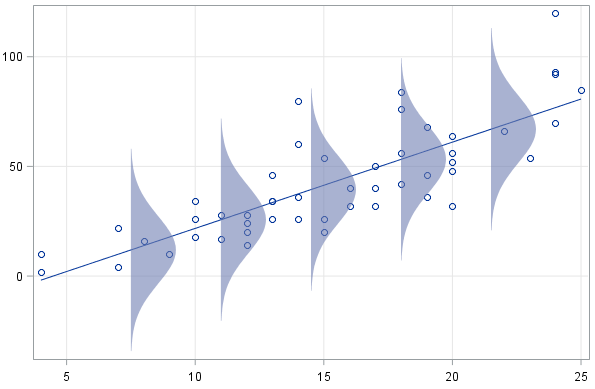

The line itself is the **expected value** of the response variable for a given value of $x$. That is, $E(y) = \hat{y} = \beta_0 + \beta_1x$. Sometimes this expression is called the model’s *deterministic component*, while $\epsilon$ is the model’s *random component*.

$~$

### Utilizing Linear Regression

Using a linear regression model to analyze data involves the following steps:

1. **Model Specification** - Specify the model at the population level, for example: $\text{Sale Price} = \beta_0 + \beta_1 \text{Assessed Value} + \epsilon$ for *all* homes located in Iowa City, IA
2. **Model Fitting** - Use the sample data to *estimate* the model’s unknown parameters (ie: estimate $\beta_0$ and $\beta_1$)
3. **Inference** - Use the fitted model to draw conclusions about the population, or make predictions about new data

In the next section, we’ll take a closer look at Step #2 using the “Tips” dataset, which is introduced below.

This dataset was recorded by a restaurant server at a national chain restaurant located in a suburban shopping mall near New York City. The server kept records on every table they served over the span of several months in hopes of better understanding the tips they’d been earning. In this lab, we’ll focus on the variables “Tip” and “TotBill”, or the amount tipped and the total bill (respectively).

```r
## Code to load the Tips dataset
tips <- read.csv("https://remiller1450.github.io/data/Tips.csv")
```

**Question #1**: Create a scatterplot displaying the relationship between “TotBill” and “Tip”. Based upon this graph, does a simple linear regression model seem reasonable for using “TotBill” to explain “Tip”?

$~$

### Model Fitting

Linear regression models are specified at the *population-level*, then the unknown parameters are estimated from the sample data.

In this class, we’ll use “hats” to denote an estimate. So, $\hat{\beta}_0$ and $\hat{\beta}_1$ represent estimates of the population-level intercept and slope. For example, we can write out the estimated/fitted model (using generic terms) in our Iowa City home sales example as:

$$\widehat{Sale Price} = \hat{\beta}_0 + \hat{\beta}_1 \text{Assessed Value}$$

As we’ve previously discussed, there are infinitely many possibilities for these estimates. That is, the family of straight-line models contains infinitely many lines. We want the *best estimates*, an idea we’ll need to more rigorously define.

**Question #2**: Considering the “Tips” dataset, write out the *population-level model* that uses “TotBill” to predict “Tip”. Then, write out the *estimated model* (in generic terms).

$~$

### Least Squares Estimation

Least squares estimation is most widely used method for finding the “best” estimates of the model’s slope and intercept. The method is based upon the **residuals**, or deviations from the regression line and the observed value of $y$. More specifically, the estimates are the values that minimize the *sum of squares* of these deviations.

Mathematically, we’ll use $r_i = y_i - \hat{y}_i$ to denote the residual of the $i^{th}$ data-point. Then, we’ll denote the *sum of squares residuals* as:

$$SSE = \sum_{i=1}^{n} (y_i - \hat{y}_i)^2$$
Notice $SSE$ is a function of $\hat{\beta}_0$ and $\hat{\beta}_1$ because $\hat{y}_i = \beta_0 + \beta_1x$; so, we could find estimates that minimize $SSE$ by taking partial derivatives with respect to $\hat{\beta}_0$ and $\hat{\beta}_1$, setting these derivatives equal to zero, then solving the resulting system of equations.

Minimizing $SSE$ to find the *least squares estimates* of $\beta_0$ and $\beta_1$ is a very important idea, but I believe there are better ways to spend our time than re-deriving the least squares estimates for ourselves. If you’re interested in the mathematical details of these estimates, [this video](https://www.youtube.com/watch?v=ewnc1cXJmGA) provides an excellent derivation.

**Question #3**: Consider the following estimated model: $\widehat{Sale Price} = -1.53 + 1.03* \text{Assessed Value}$. One home in dataset had an assessed value of $173040 and sold for $172500 (case #1), while another home had an assessed value of $679540 and sold for $550000 (case #14). Use this estimated model to calculate the *residuals* for each of these observations (you can call them $r_1$ and $r_{14}$). Which observation (case #1 or case #14) do you think had a greater influence on the least squares estimates?

$~$

### The `lm` Function

In `R`, the `lm` function will fit linear regression models using *least squares estimation*. The example below demonstrates how to use this function, along with a few related functions that are used to access the quantities mentioned in previous sections:

```r
## Load Iowa City Home Sales data
ic <- read.csv("https://remiller1450.github.io/data/IowaCityHomeSales.csv")

## Fit model using "lm"
model <- lm(sale.amount ~ assessed, data = ic)

## Get the estimated coefficients
coef(model)
```

```
## (Intercept)    assessed
##   -1.522832    1.033127
```

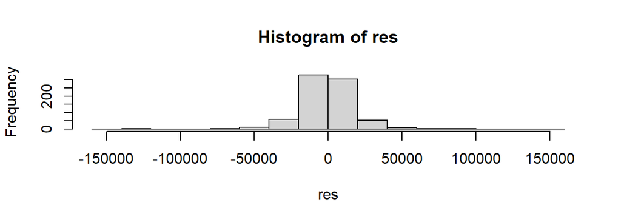

```r
## Get the residuals
res <- residuals(model)

## Histogram of the residuals
hist(res)
```

```r
## Sum of squares residuals
sum(res^2)
```

```
## [1] 3.40932e+11
```

**Question #4**: Use the `lm` function to estimate the slope and intercept for the linear regression that relates “TotBill” and “Tip”. Report these estimates using proper statistical notation and provide a brief interpretation of each.

**Question #5**: Using the model you fit in Question #4, use the `which.min` function to locate the index of the largest negative residual. Next, find this observation in the dataset and calculate the percentage of the total bill that this person(s) tipped.

**Question #6**: Use the `sum` function to sum-up all of the model’s residuals (*do not* square them). Are you surprised by the result? Briefly explain.

$~$